# Optimizing Newsletter Metrics Through Data Collection, Analysis, and Visualization

# Campaign Data Analysis

### Successful Deliveries Correlation

First, I am looking for an overall view of our Campaign data and the relationship between the variables.

[figure not shown]

```python
ax = sns.heatmap(metrics.corr()[['Successful Deliveries']].sort_values('Successful Deliveries'),cmap = 'coolwarm',annot = True,
           xticklabels = True).set_title("Successful Deliveries and Metrics")
plt.yticks(rotation=0)
```

This graph shows the relationship between successful newsletter deliveries and the other metrics we are observing. As expected, hard bounces and successful deliveries have a very low correlation.

### A closer look: Hard Bounces

The [Hard Bounces](https://mailchimp.com/help/soft-vs-hard-bounces/) column is important to dive into. Hard bounces can occur for several reasons: the recipient email address doesn't exist, the domain name doesn't exist, or the recipient email server has completely blocked delivery.

#### Successful Deliveries vs Hard Bounces

Here, I am using seaborn's scatterplot functionality.

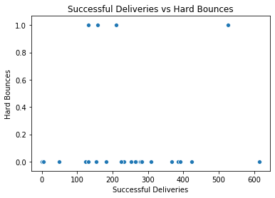

```python
sns.scatterplot(metrics["Successful Deliveries"], metrics["Hard Bounces"]).set_title("Successful Deliveries vs Hard Bounces")
```

#### Hard Bounces per Campaign

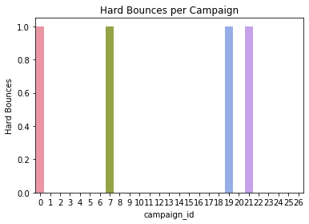

```python
sns.barplot(metrics['campaign_id'],
            y = metrics["Hard Bounces"],
           ).set_title("Hard Bounces per Campaign")
```

These graphs show that there have only been a few instances of hard bounces in the overall history of the newsletter. Mailchimp makes an effort to clean subscriber lists, so if it detects a hard bounce it unsubscribes the contact. This explains the sparseness of these graphs.

### A closer look: Soft Bounces

Now, I want to look at the [Soft Bounces](https://mailchimp.com/help/soft-vs-hard-bounces/) metric. Compared to hard bounces, soft bounces can occur for several reasons. Inclunding, the recipients mailbox is full, the recipient email server is down or offline, or the email message is too large. Here are the same graphs as above, but looking using this metric.

#### Successful Deliveries vs Soft Bounces

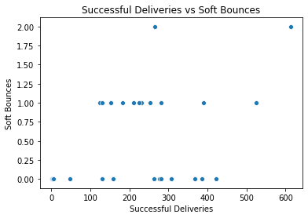

```python
sns.scatterplot(metrics["Successful Deliveries"], metrics["Soft Bounces"]).set_title("Successful Deliveries vs Soft Bounces")
```

#### Soft Bounces per Campaign

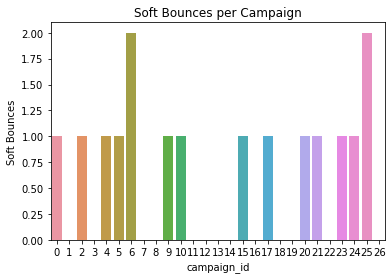

```python
sns.barplot(metrics['campaign_id'],
            y = metrics["Soft Bounces"],
           ).set_title("Soft Bounces per Campaign")
```

These are helpful and telling of the difference in frequency between soft and hard bounces. Because this difference is my biggest takeaway from these graphs, I am going to visualize a comparison between the two metrics.

### Soft Bounces vs Hard Bounces

#### First, I am taking several steps to keep the data organized and get the outcome closest to what I am looking for.

To begin, I am copying the metrics dataframe, using only the columns I am interested in. I am calling the new dataframe bouncedf.

```python
bouncedf = metrics[['campaign_id', 'Soft Bounces', 'Hard Bounces']].copy()
```

The next step I am taking involves creating a pivot table from bouncedf. I am doing this to stay organized and look at only the information I am currently investigating for.

```python
bounce_table = pd.pivot_table(bouncedf, values = ["Soft Bounces", "Hard Bounces"], index = "campaign_id", aggfunc = np.mean)
bounce_table.head()
```

| campaign_id | Hard Bounces | Soft Bounces |
| --- | --- | --- |
| 0 | 1 | 1 |
| 1 | 0 | 0 |
| 2 | 0 | 1 |
| 3 | 0 | 0 |
| 4 | 0 | 1 |

Now, I am coding the plot using a for loop to access all the columns that I need. The input will be a list of the metrics I am looking for.

```python
def bounce_type(measures):
    fig, ax = subplots(figsize=(10,5))
    for x in measures:
        bounce_table.groupby(['campaign_id']).mean().plot(kind = 'bar', ax = ax, grid = True)
    ax.set_ylabel('Bounces')
    ax.set_title('Bounces per Campaign')
    ax.set_xlabel("Campaign ID")
    ax.legend(measures)
    return ax
```

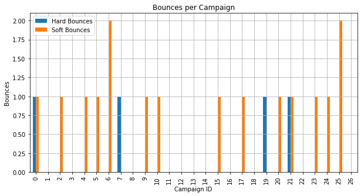

```python
ax = bounce_type(['Hard Bounces', 'Soft Bounces'])
```

As you can see, soft bounces are much more common that hard bounces and in many cases, the contacts that bounce are cleared from the sending list.

## Total Opens by Campaign ID

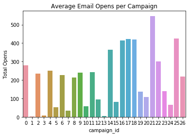

```python
sns.barplot(metrics['campaign_id'],
            y = metrics["Total Opens"],
           ).set_title("Average Email Opens per Campaign")
```

This graph is helpful, but may be difficult to understand without context. Out of curiosity, I have been resending to non-openers-- it has not proved very useful. Additionally, The Root is sent out every Monday morning, sometimes I have seen a spike in subscribers on that day and have sent the campaign to those people. Because it is a smaller list, the opens are smaller.

## Total Clicks vs Unique Clicks

Now, I am using seaborn's [lmplot.](https://seaborn.pydata.org/generated/seaborn.lmplot.html) It is useful because it provides a regression line. This helps with gaining insight in overall expectations for the future.

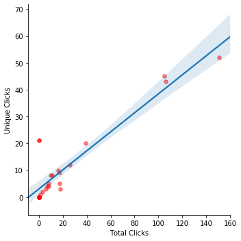

```python
plt.figure(figsize = (25,25))
sns.lmplot(x="Total Clicks", y = "Unique Clicks", scatter_kws={"color":"red","alpha":0.5
                                                                     ,"s":30}, data = metrics)
```

This graph is interesting because it shows that usually a subscriber who clicks, will click around 2 times throughout the newsletter.

## Unique Opens vs Total Recipients

Again, I am using seaborn's lmplot functionality to measure consistency between Total Recipients and Unique Opens. I am pretty proud of the results.

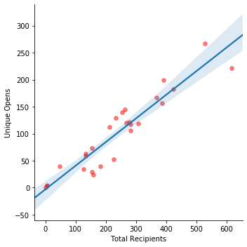

```python
plt.figure(figsize = (25,25))
sns.lmplot(x='Total Recipients',y='Unique Opens',fit_reg=True,scatter_kws={"color":"red","alpha":0.5
                                                                     ,"s":30},data=metrics)
```

This graph shows the positive correlation between Total Recipients and unique opens. This is interesting to see because as the list has grown, people have continued opening emails. This is opposed to a [dead list](https://blog.3dcart.com/engage-dead-email-list)-- where the number of subscribers is high but the actual engagement is close to nothing.

# Time Analysis

## Metrics over time

### A closer look: by Month

In order to see how opens have progressed over time, I am creating a column called month. I am doing this using the (very helpful) [pandas DateTimeIndex](https://pandas.pydata.org/pandas-docs/stable/reference/api/pandas.DatetimeIndex.month.html) functionality.

```python
metrics['month'] = metrics.index.month
newdf = metrics[['Total Recipients', 'Unique Opens', 'Unique Clicks', 'month']].copy()
newdf.set_index("month", inplace = True)

month_table = pd.pivot_table(newdf, values = ["Total Recipients", "Unique Opens", "Unique Clicks"], index = "month", aggfunc = np.mean)
month_table
```

| month | Total Recipients | Unique Clicks | Unique Opens |
| --- | --- | --- | --- |
| 8 | 138.166667 | 1.5 | 70.166667 |
| 9 | 209.800000 | 4.3 | 79.000000 |
| 10 | 322.428571 | 26.0 | 153.142857 |
| 11 | 308.000000 | 10.5 | 110.500000 |

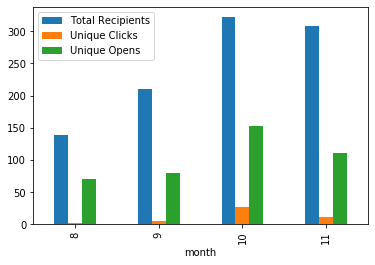

```python
month_table.plot(kind = 'bar')
```

This visualization tells me that the last few campaigns have not had as many opens as ones before. It will be interesting to note why/what can be done with this data to improve.

I am going to take a look at this data through a line graph.

```python
metrics['month'] = metrics.index.month

def by_month(measures):
    fig, ax = subplots(figsize=(10,5))
    for x in measures:
        month_table.groupby('month').mean().plot(kind = 'line', ax = ax, grid = True)
    ax.set_ylabel('# of Individuals')
    ax.set_title('Metrics by Month')
    ax.set_xlabel("Month")
    ax.legend(measures)
    return ax
```

[figure not shown]

```python
ax = by_month(['Unique Opens', 'Unique Clicks', 'Total Recipients'])
```

## Metrics by Hour

I am going to separate out hour from our time index. Through this, I hope to gain some insight into how powerful time is when sending out a newsletter.

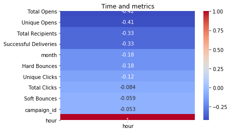

```python
metrics['hour'] = metrics.index.hour
ax = sns.heatmap(metrics.corr()[['hour']].sort_values('hour'),cmap = 'coolwarm',annot = True,
           xticklabels = True).set_title("Time and metrics")
plt.yticks(rotation=0)
```

Through the heatmap above, I can see the relationship hour has to the various metrics. Notably, hour and Total Opens have the lowest correlation. I was not expecting this.

```python
metrics['hour'] = metrics.index.hour

def by_hour(measures):
    fig, ax = subplots(figsize=(10,5))
    for x in measures:
        metrics.groupby('hour').mean().plot(kind = 'line', ax = ax, grid = True)
    ax.set_ylabel('# of Individuals')
    ax.set_title('Unique Engagement per Hour')
    ax.set_xlabel("Hour")
    ax.legend(measures)
    return ax
```

I created the function above to get a closer look into the relationship between hour and various important newsletter metrics such as Unique Opens and Unique Clicks.

[figure not shown]

```python
ax = by_hour(['Unique Opens', 'Unique Clicks'])
```

## Metrics by Subject

Finally, I am curious about the Subject metric. Using the WordCloud import seems like an interesting way to explore it more. I am not sure how helpful the data will actually be for future action, though.

```python
subjects = ''
for s in metrics["Subject"]:
    subjects+=s
```

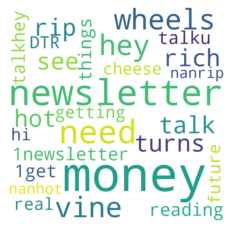

```python
stopwords = set(STOPWORDS)
wordcloud = WordCloud(width = 800, height = 800,
                background_color ='white',
                stopwords = stopwords,
                min_font_size = 10).generate(subjects)
plt.figure()
plt.imshow(wordcloud, interpolation="bilinear")
plt.axis("off")
plt.show()
```

As expected, this final exploration was more out of curiousity! It is definitely interesting to see The Root's subjects in this form.

## Conclusion and Final Thoughts

Email marketing and newsletters are popular and widely recognized as an important part of an organization's engagement with its audience. Although a ton of data exists around the topic, I have realized that without these skills, it would be nearly impossible to have a clear view on how my newsletter, The Root, has grown over time.

I look forward to continue exploring the data I gather through my newsletter. Hopefully, knowing how to analyze and look into data beyond what Mailchimp offers will help me make more concrete, data-driven decisions. Thanks for reading!